# Lecture 04: The `ggplot` library

## 2.3.2 Justify the axis text through `theme()` and `hjust`

We've updated the angle of our text but they're positioned on somewhat of a "centred" alingment. We then justify the labels such that they align with the x-axis.

You may ask why this is a horizontal (hjust) justification, when it seems like moving the labels upwards towards the x-axis should be a vertical (vjust) justification. If you look in the help menu at `element_text()` you will see that the justification is carried out before the rotation. While we can specify the parameters of `element_text()` in any order, this does not change the order they are executed in the function.

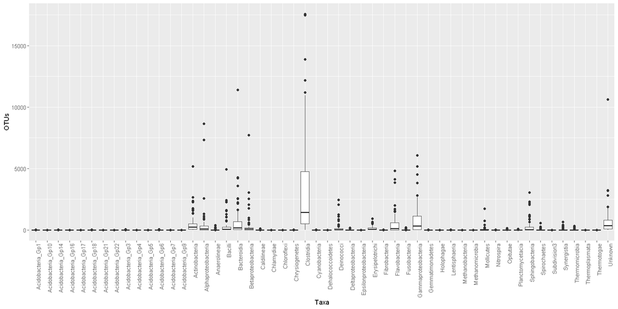

```r
# Update our plot to push our text to align with the x-axis
ggplot(latrines) +
    aes(x = Taxa, y = OTUs) +
    geom_boxplot() +
    theme(axis.text.x = element_text(angle = 90, hjust=1))
```

While it is clear that Clostridia is the most represented taxa, it is difficult to tell whether some other taxa have no representation, or if they are lowly represented. Transforming to a log scale on the y-axis will sort this out for us.

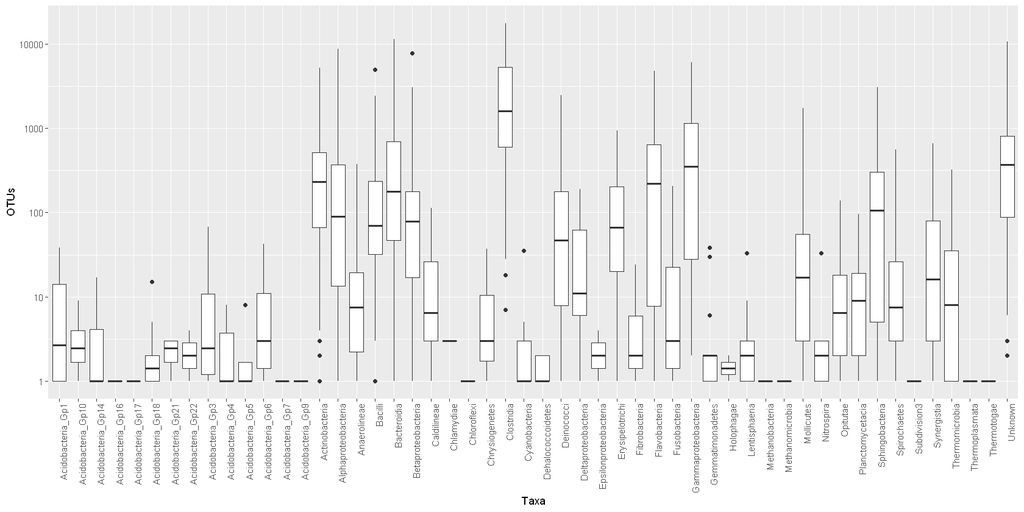

```r
# Transform our y-axis to the log scale
ggplot(latrines) +
    aes(x = Taxa, y = OTUs) +
    geom_boxplot() +
    theme(axis.text.x = element_text(angle = 90, hjust = 1)) +
    scale_y_log10() # remember: this is not transforming the data in the y axis but just rearranging the y axis
```

## 2.3.3 Slice your data to display what you'd like

For now, let's just keep the Taxa that are common to both countries and have greater than 1 OTU counts. To do this we can revisit our favourite `dplyr` verbs

1. filter for rows with greater than or equal to 2 OTUs (already completed in 2.2.0 with `filtered_latrines`
2. `group_by()` Country and Taxa to get Country-specific information about Taxa
3. count the number of entries, `filter()` Taxa that are shown to appear in more than one sample.
4. We then need to `ungroup()` to select our final list or we will end up with a grouped object.
5. We use the `duplicated()` function to retain those Taxa that were found twice (ie. in both countries).

The `%in%` function returns a logical vector of whether there is a match or not for its first argument in its second argument. It is useful for subsetting.

We can facet our plot by Country to verify we have only commonly appearing OTUs.

```r
keep <- filtered_latrines %>%
    group_by(Country, Taxa) %>%
    summarize(n = n())  %>%  #count the number of entries
    filter(n > 1)  %>% # get rid of any entries with only a single sample
    ungroup()  %>% # remove the grouping
    select(Taxa)  %>%  # look only at the Taxa column
    filter(duplicated(.)) # keep only the samples that are listed twice (ie in both countries)

head(keep)
# Make a new object that filters your taxa
sub_filtered_latrines <- filtered_latrines  %>% filter(Taxa %in% keep$Taxa)
```

A tibble: 6 × 1

| Taxa <chr> |
| --- |
| Acidobacteria_Gp3 |
| Actinobacteria |
| Alphaproteobacteria |
| Anaerolineae |
| Bacilli |
| Bacteroidia |

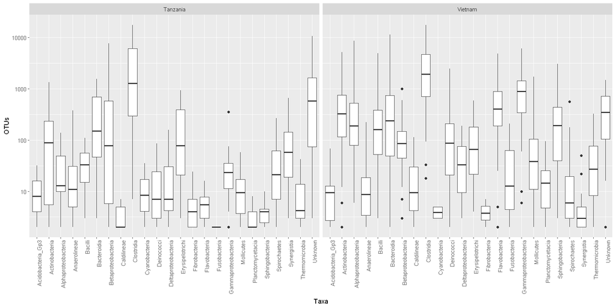

```r
# Plot that graph!
ggplot(sub_filtered_latrines) +
    aes(x = Taxa, y = OTUs) +
    geom_boxplot() +
    theme(axis.text.x = element_text(angle = 90, hjust = 1)) +
    scale_y_log10() +
    facet_grid(~Country)
```

We will be using this graph as a base for customization later in the lesson.

## 2.4.0 Beeswarm Plots show us all or our data points

Even though boxplots give us summary statistics on our data, it is useful to be able to see where our individual data points are. We can add the data as another layer using `geom_point()`to place dots on top of our boxplot, or use `geom_jitter()` to spread our points out a bit. However, a **beeswarm plot** places data points that are overlapping next to each other, so we can get a better picture of the distribution of our data.

I have subset the data to make a boxplot with 3 Taxa and 1 Country so that we can see the differences in geom options a bit better.

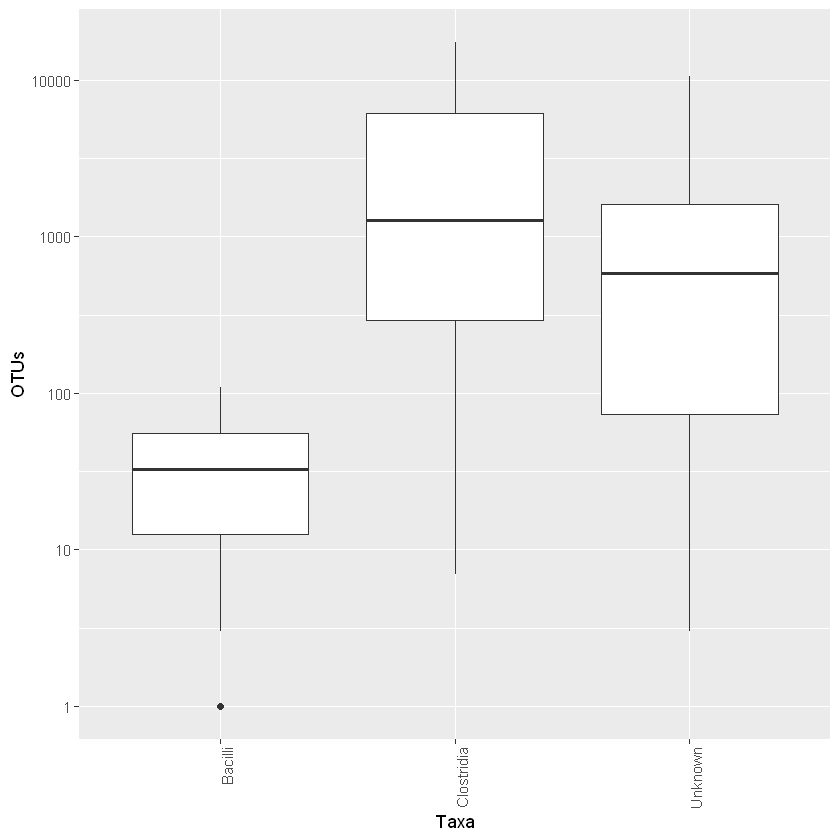

```r
# Reset image sizes for our comfort
options(repr.plot.width=7, repr.plot.height=7)

# Select only taxa from Tanzania that is either Clostridia, Unknown, or Bacilli
subdat <- latrines %>% filter((Taxa=="Clostridia" | Taxa == "Unknown" | Taxa == "Bacilli") &
                                Country == "Tanzania")

b <- ggplot(subdat) +
    aes(x = Taxa, y = OTUs) +
    geom_boxplot() +
    theme(axis.text.x = element_text(angle=90, hjust=1)) +
    scale_y_log10()

b
```

## 2.4.1 You can store ggplot objects as variables that you can continue to update

As you can see above, an option with `ggplot2` is to save your plot into a *ggplot object*. This works well if you know you are only changing one or two elements of your plot, and you do not want to keep retyping code. What we are going to vary here is how the data points are displayed.

Now, we can simply overlay the points with `geom_beeswarm()`.

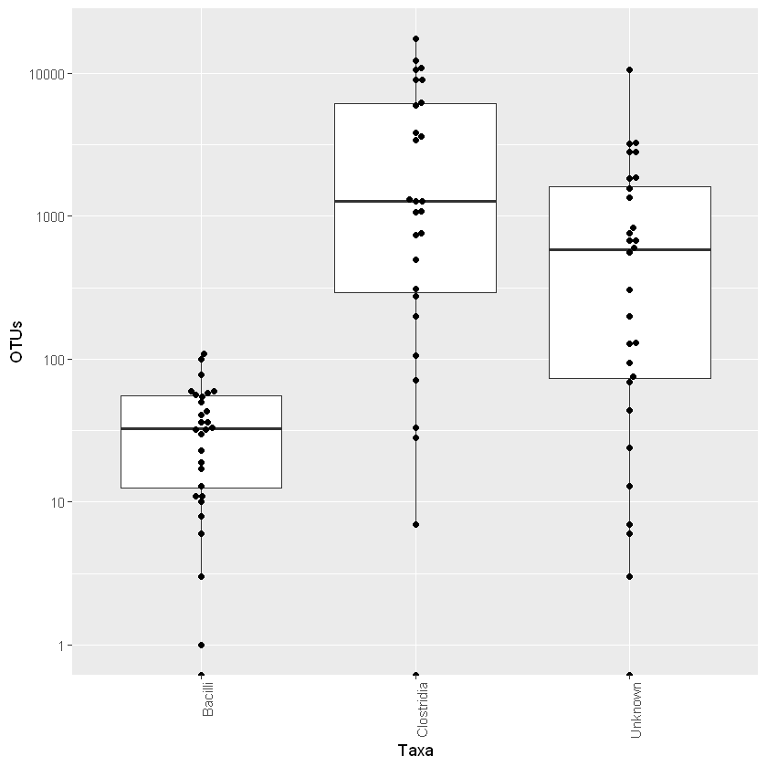

```r
# Load the ggbeeswarm package
library(ggbeeswarm)

# Add a geom to our saved plot
b + geom_beeswarm()
```

## 2.4.2 `cex` is a common parameter used to adjust plotting properties of text and symbols

Depending on the function or geom you may often find that the `cex` parameter can be adjusted to alter some aspect of how a geom or other graphical layer is displayed. In the case of `geom_beeswarm()` we can increase the spacing between data points to make its distribution a bit clearer.

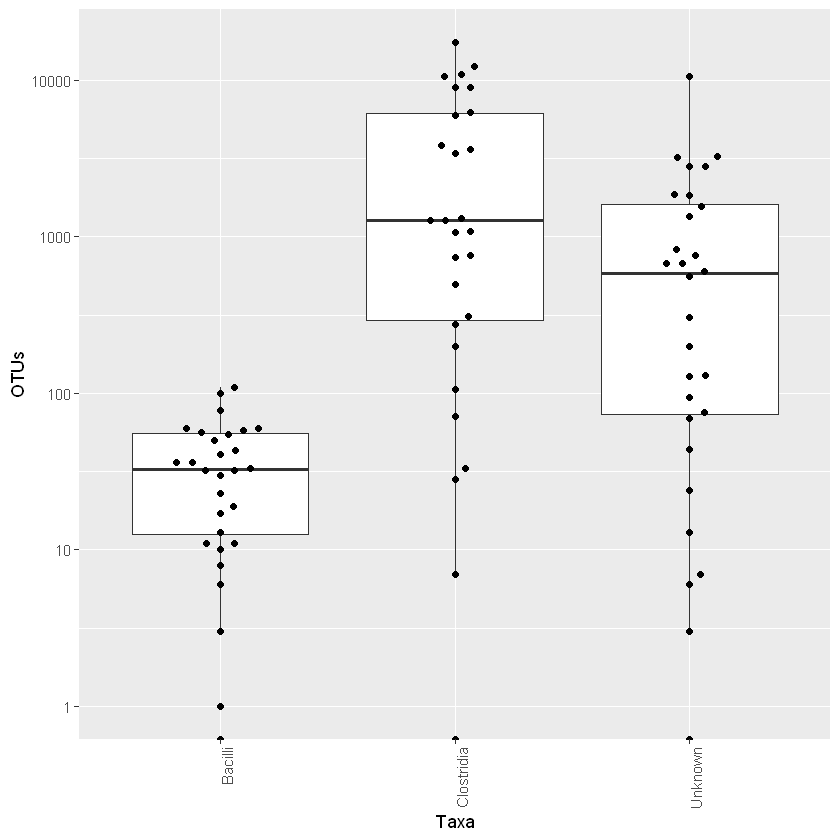

```r
# Update the cex parameter
b + geom_beeswarm(cex = 2.2)
```

## 2.4.3 Reduce overplotting with `geom_quasirandom()`

If you think you will have many points to display or if you want to avoid adjusting parameters with each new plot, consider using a `geom_quasirandom()` to give the empirical distribution of the stripplot to avoid overplotting. It is a geom included with the `ggbeeswarm` package and can simplify the look and creation of your plots

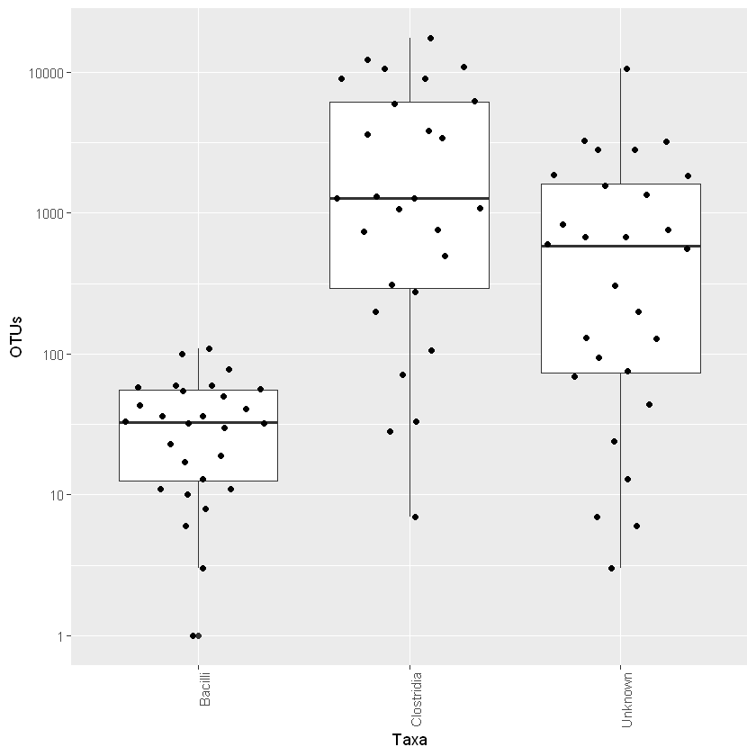

```r
# replace geom_beeswarm() with a geom_quasirandom()
b + geom_quasirandom(varwidth = TRUE)
```

Other spacing and distribution options are available at https://github.com/eclarke/ggbeeswarm.

## 3.0.0 Customizing your plots

[figure not shown]

## 3.0.1 Attributes Related to Your Data

Up to this point, we've discussed some of the ways to alter our plots in ways to best visualize our data by dabbling with `colour`, `fill`, `shape`, and `position`. This has been accomplished mostly through the `aes()` attribute. Depending on the nature of the layers or elements you add, we can alter their characteristics indidually to customize.

Plot elements relating to your data include things like axis labels, titles, colour or shapes that represent subsets of your data, scaling that is data-dependent, legends, and other data-driven parameters.

For customizing your data it is possible to change:

- `colour()`
- `fill()`
- `shape()`
- `size()`
- `alpha()`

Titles and axis labels can be added using:

- `ggtitle()`
- `xlab()`
- `ylab()`

We have seen in the above examples that colour can be applied to discrete or continuous variables. We can also use colour (shape, etc.) to represent outliers. In this dataset, outliers beyond the whiskers (above or below 1.5*IQR) can be coloured red.

Let's review our base graph:

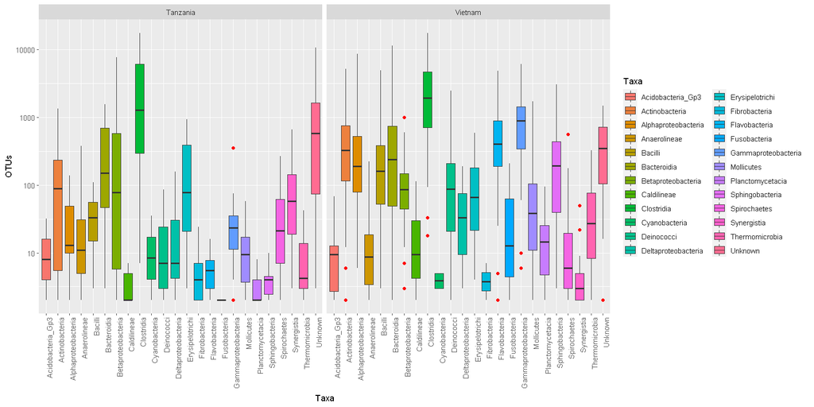

```r
# Reset image sizes for something a little wider
options(repr.plot.width=14, repr.plot.height=7)

ggplot(sub_filtered_latrines) +
    aes(x = Taxa, y = OTUs, fill = Taxa) + # fill our boxplots with color based on Taxa
    geom_boxplot(outlier.colour = "red") + # Specify the colour of outliers
    theme(axis.text.x = element_text(angle = 90, hjust = 1)) + # Rotate the text on the x-axis
    scale_y_log10() +
    facet_grid(~Country)
```

## 3.1.0 Adding a title and including axis labels

Let's start off by sprucing up our plot with

- `ggtitle()` to add a title
- `ylab()` to rename for those less acquainted with the OTU acronym
- `xlab()` to remove the "Taxa" label
- `guides()` to remove the legend

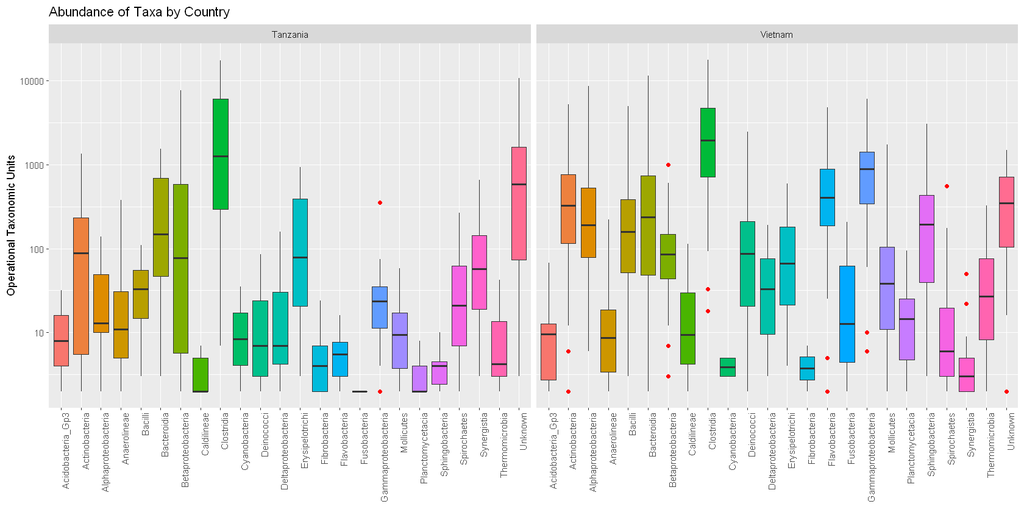

```r
# Start with our base plot
ggplot(sub_filtered_latrines) +
    aes(x = Taxa, y = OTUs, fill = Taxa) +
    geom_boxplot(outlier.colour = "red") +
    theme(axis.text.x = element_text(angle = 90, hjust = 1)) +
    scale_y_log10() +
    facet_grid(~Country) +

# Update our titles and remove the legend
    ggtitle("Abundance of Taxa by Country") +
    xlab(NULL) +
    ylab("Operational Taxonomic Units") +
    guides(fill=FALSE)
```

## 3.1.1 Assigning or alter labels on your plot

I also want to capitalize the Country labels. This can be done in a couple of ways.

One way would be to change the values in the dataset using string manipulation. A second way, would be using the `labeller()` function. I can make a vector of the capitalized names to replace **'Tanzania'** and **'Vietnam'**. The data is split by Country in the `facet_grid()` and this is where we pass our labels to `labeller()`, which will output the names on the strip label.

I am now going to save this plot in a *ggplot object*, since we are going to use this as our base plot for the next section. I am also going to rotate the x-axis text again. We will talk about theme elements soon, but in the meantime it won't drive me bonkers.

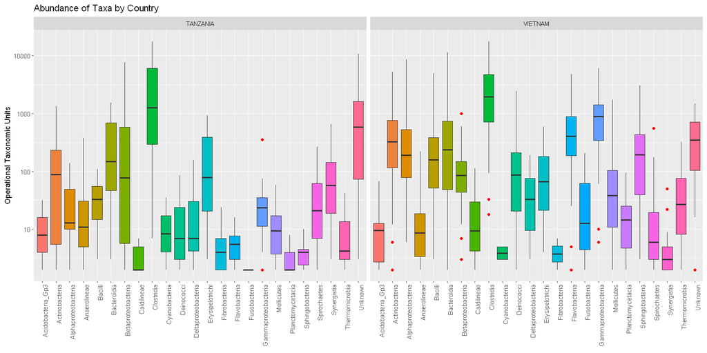

```r
# Make a list for our labels
labels <- c(Tanzania = "TANZANIA", Vietnam = "VIETNAM")

# Assign our plot to an object for alteration later on
my_plot <- ggplot(sub_filtered_latrines) +
    aes(x = Taxa, y = OTUs, fill = Taxa) +
    geom_boxplot(outlier.colour = "red") +
    theme(axis.text.x = element_text(angle = 90, hjust = 1)) +
    scale_y_log10() +

    # here I pass labels to the plot through the facet_grid() layer
    facet_grid(~Country, labeller = labeller(Country = labels)) + # here I pass labels to the plot

    # continue adding our labels
    ggtitle("Abundance of Taxa by Country") +
    xlab(NULL) +
    ylab("Operational Taxonomic Units") +
    guides(fill=FALSE)

# display our plot
my_plot
```

## 3.2.0 Colour palettes!

A common thing to want to do is to change colours from `ggplot2`'s default rainbow palette. There are many reasons to change a colour palette including

- making it easier on the reader's eye
- making it colour-blind friendly
- plots with continuous data should use good colour spectra for accurate representation

Let's create our own colour palette for Taxa.

## 3.2.1 A Note on Colour Palettes

There are 3 main types of colour palettes.

### 3.2.1.1 Use sequential colour palettes to display low to high values

*Sequential* - implies an order to your data - i.e. light to dark implies low values to high values, e.g. heatmaps.

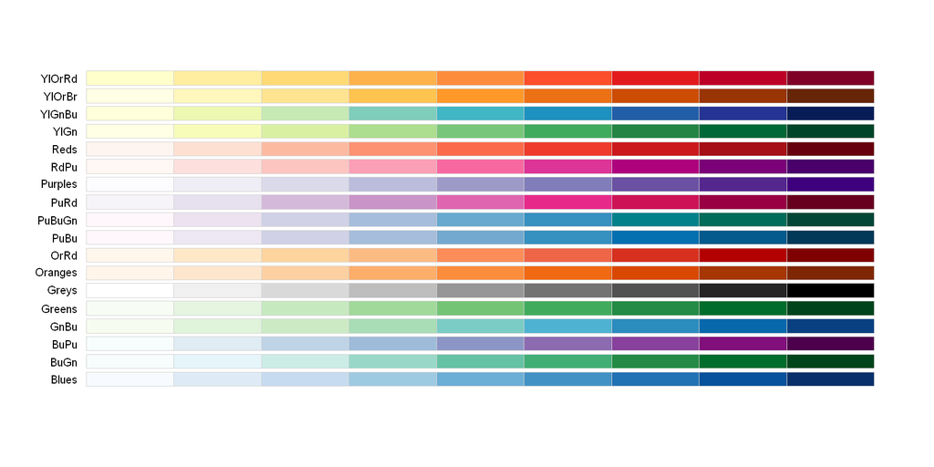

```r
# Load the RColorBrewer library
library(RColorBrewer)

# display the sequential colour palettes
display.brewer.all(type = "seq")
```

### 3.2.1.2 Use diverging colour palettes to highlight the middle and extremes of a distribution

*Diverging* - low and high values are extremes, and the middle values are important - still goes from light to dark, but 3 colours mainly used.

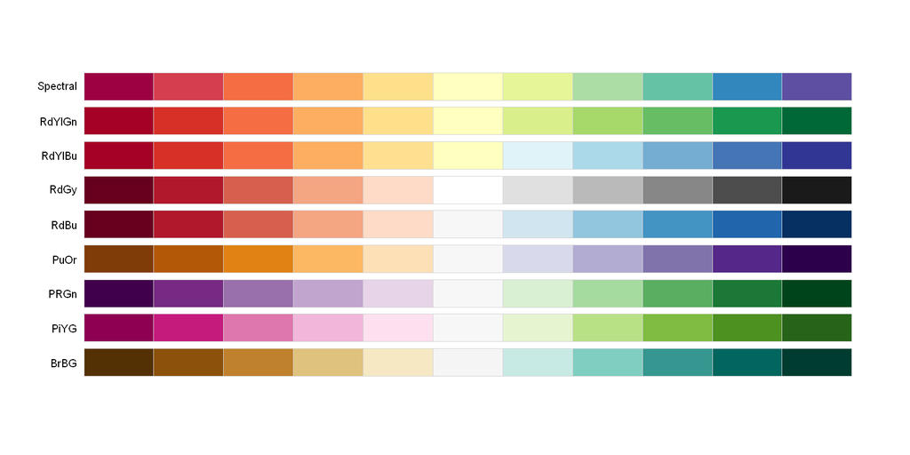

```r
# Display the diverging colour palettes
display.brewer.all(type = "div")
```

### 3.2.1.3 Use qualitative colour palettes for categorical data

1. *Qualitative* - there is no quantitative relationship between colours. This is usually used for categorical data.

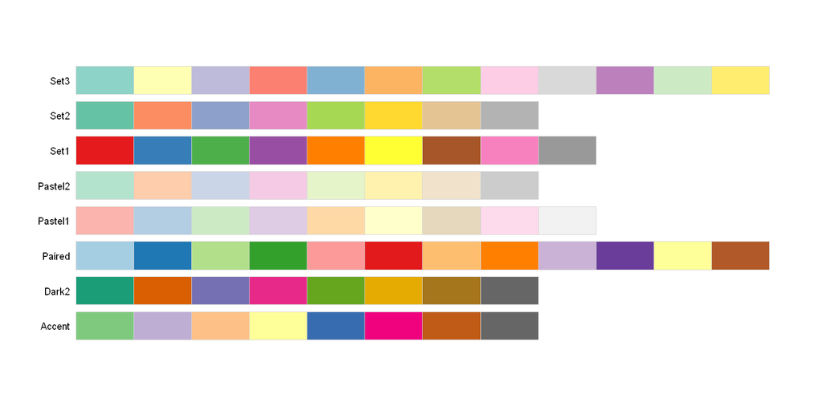

```r
display.brewer.all(type = "qual")
```

## 3.2.2 Add a colour palette to a plot like a layer

Let's test one of the `RColorBrewer` palettes out on our data. We'll add it as a layer to `my_plot` using `scale_fill_brewer()` to override the fill mappings defined in the `aes()` layer of the plot.

```
Warning message in RColorBrewer::brewer.pal(n, pal):
"n too large, allowed maximum for palette Spectral is 11
Returning the palette you asked for with that many colors
"
```

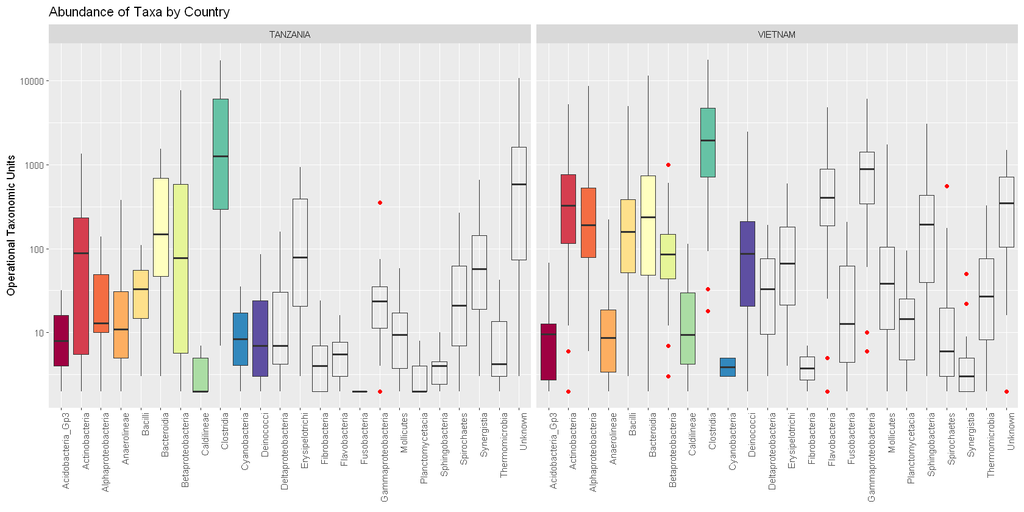

```r
my_plot + scale_fill_brewer(palette = "Spectral")
```

### 3.2.2.1 Colour palettes are not vector recycled when plotting in `ggplot`

Notice the warning we received: "n too large..."? Note that we have **24** different taxa along our x-axis but the `Spectral` palette only has **11** colours. Unlike when we see vector recycling in previous lectures, this does not occur when supplying a colour palette to our plot. In generating our plot, we only colour the first **11** colours.

## 3.2.3 `RColorBrewer` colour palettes can be created with `brewer.pal()`

Many colour palettes now exist. I'll showcase a couple that work nicely with `ggplot2`. These packages also have colorblind friendly options. `RColorBrewer` has options for these 3 types of palettes, which you can see with `display.brewer.all()`. With a smaller dataset, we could make a call in `ggplot` directly to `scale_fill_brewer()`, which just requires a choice of one of `RColorBrewer`'s palettes, such as "Spectral". However, we have 24 Taxa and these palettes have 8-12 colours, so we have to get creative.

Using the `brewer.pal()` function, we can pull different colours from palettes of our choosing. In our case, I have simply taken the 2 qualitative palettes that each have a length of 12, put them into one palette, and made sure my values were unique. This can then be passed to `ggplot` via `scale_fill_manual()`.

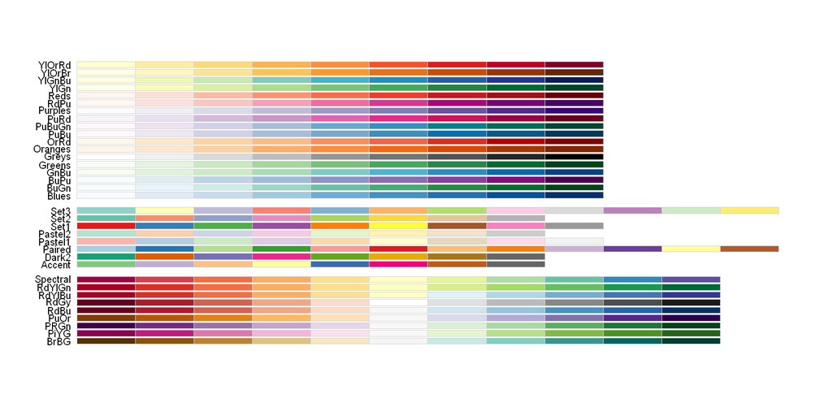

```r
display.brewer.all()
```

```r
# Generate 2 palettes from the longest ones
palette1 <- brewer.pal(12, "Paired")
palette2 <- brewer.pal(12, "Set3")

# combine into a single palette
custom <- unique(c(palette1, palette2))

# Do we still have enough colours?
length(custom)
custom
```

24

1. '#A6CEE3'

2. '#1F78B4'

3. '#B2DF8A'

4. '#33A02C'

5. '#FB9A99'

6. '#E31A1C'

7. '#FDBF6F'

8. '#FF7F00'

9. '#CAB2D6'

10. '#6A3D9A'

11. '#FFFF99'

12. '#B15928'

13. '#8DD3C7'

14. '#FFFFB3'

15. '#BEBADA'

16. '#FB8072'

17. '#80B1D3'

18. '#FDB462'

19. '#B3DE69'

20. '#FCCDE5'

21. '#D9D9D9'

22. '#BC80BD'

23. '#CCEBC5'

24. '#FFED6F'

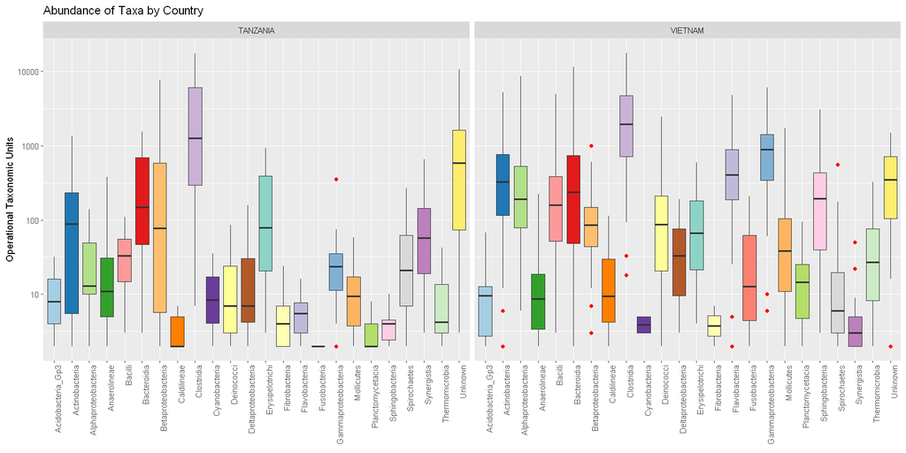

```r
# Update our plot by adding colour
my_plot + scale_fill_manual(values = custom)
```

## 3.2.4 You can always pick your own colours

You can always choose a vector of your own colors using this 'R color cheatsheet' (https://www.nceas.ucsb.edu/~frazier/RSpatialGuides/colorPaletteCheatsheet.pdf).

Names of colours as well as hex colour codes are accepted.

```r
# Reminder of how the rep() command works
rep(c(1,2,3,4), 4)
```

1. 1

2. 2

3. 3

4. 4

5. 1

6. 2

7. 3

8. 4

9. 1

10. 2

11. 3

12. 4

13. 1

14. 2

15. 3

16. 4

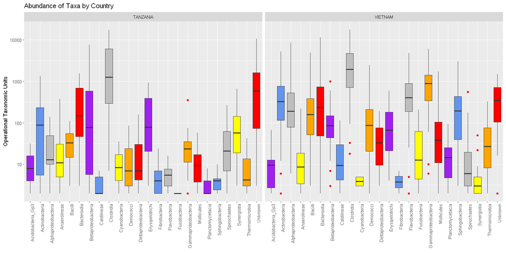

```r
# Fill the boxplot using a rep() command
my_plot + scale_fill_manual(values=rep(c("purple", "cornflowerblue", "grey", "yellow", "orange", "#FF0000"), 4))
```

## 3.2.5 Colour-blind friendly palettes can be found in the `viridis` package

The `viridis` package also has some nice color palettes (https://cran.r-project.org/web/packages/viridis/vignettes/intro-to-viridis.html). I think they might all be diverging palettes (qualitative is best for our Taxa), but I will showcase a couple here.

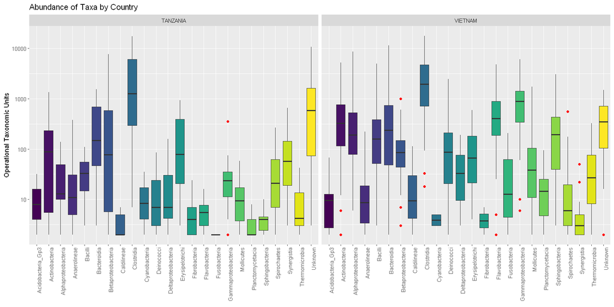

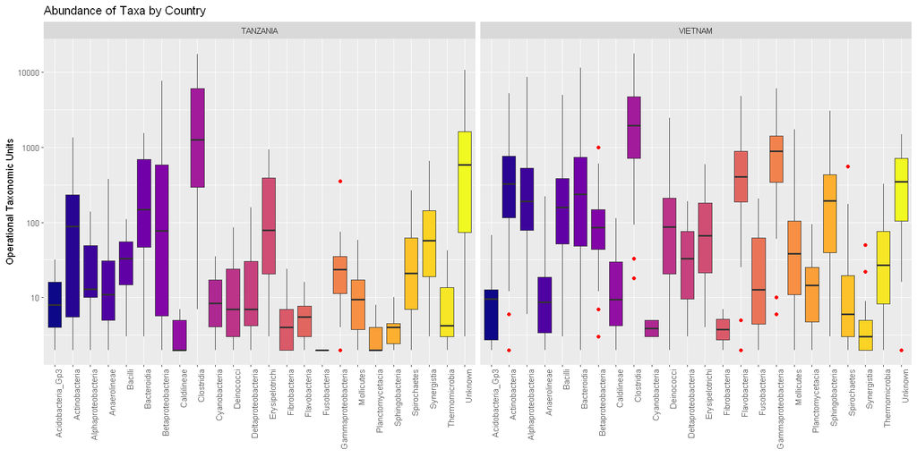

```r
# Load the viridis package
library(viridis)

# Example 1 with viridis
my_plot + scale_fill_viridis(discrete = TRUE)

# Example 2 with viridis (plasma)
my_plot + scale_fill_viridis(discrete = TRUE, option = "plasma")
```

`RSkittleBrewer` is another option for funky colour palettes. `ggsci` has a variety of color palettes inspired by different scientific journals as well as television shows (https://cran.r-project.org/web/packages/ggsci/vignettes/ggsci.html).

## 3.3.0 Theme: attributes unrelated to your data

As mentioned earlier, it is possible to customize every single aspect of a `ggplot`. Most of this occurs with a call to `theme()`, which you can think of as modifying everything BUT your data. For example, my axis labels can be modified, but they (hopefully) have something to do with my data. However, changing the size of the text or the font of the labels is unrelated to my data, and the same structure (text font & size) could be carried over to other plots if I saved my own theme.

Things that you can change with `theme()` include the axis, legend, panels, gridlines, or background.

Each *element* of a theme inherits from one of:

- `element_text` (text elements like font, colour, size, face (bold, italics), alignment),
- `element_line` (grid lines, axis lines),
- `element_rect` (panels and backgrounds - colour, size, fill),
- `element_blank` (assigns nothing, usually when you are trying to get rid of something),
- `element_grob` (making a grid grob).

`ggplot2` comes with some themes - I suggest starting with the one that is close to what you want, and start modifying from there.

Check out these *themes*:

- `theme_minimal()`
- `theme_classic()`
- `theme_bw()`
- `theme_void()`
- `theme_dark()`
- `theme_gray()`
- `theme_light()`

You can look at the default for each theme simply by typing it into the console.

```r
theme_bw
```

```
function (base_size = 11, base_family = "", base_line_size = base_size/22,
    base_rect_size = base_size/22)
{
    theme_grey(base_size = base_size, base_family = base_family,
        base_line_size = base_line_size, base_rect_size = base_rect_size) %+replace%
        theme(panel.background = element_rect(fill = "white",
            colour = NA), panel.border = element_rect(fill = NA,
            colour = "grey20"), panel.grid = element_line(colour = "grey92"),
            panel.grid.minor = element_line(size = rel(0.5)),
            strip.background = element_rect(fill = "grey85",
                colour = "grey20"), legend.key = element_rect(fill = "white",
                colour = NA), complete = TRUE)
}
```

And this is what `theme_bw()` practically looks like:

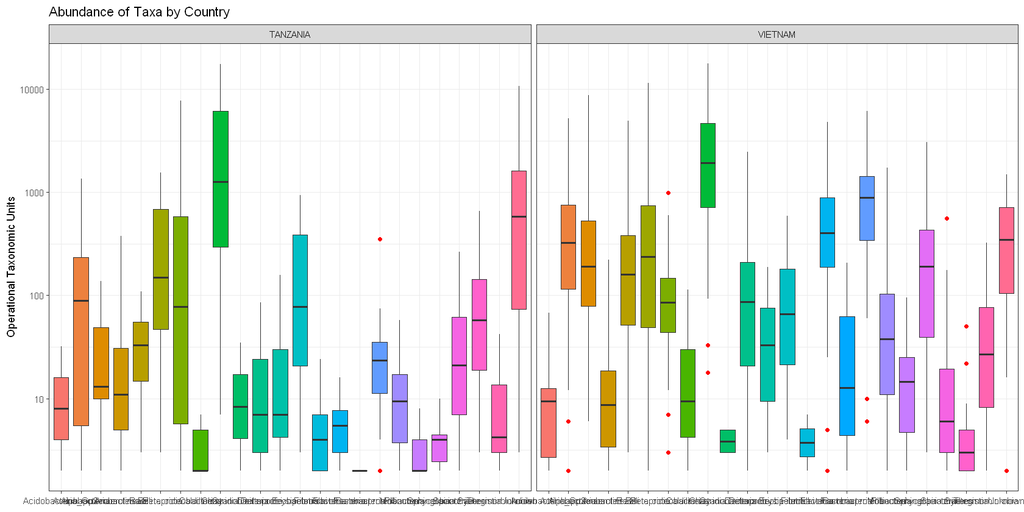

```r
# Alter the theme of my_plot
my_plot + theme_bw()
```

## 3.3.1 Remember that attribute changes are overridden by order of appearance

Notice how that last call to theme overrides my previous call to theme if there is a conflict. In this case the angle of the x-axis text is returned from a vertical to a horizontal orientation.

Here is an example of `theme_dark()`. I am going to override the default x-axis text angle of this theme by modifying it AFTER I call `theme_dark()`.

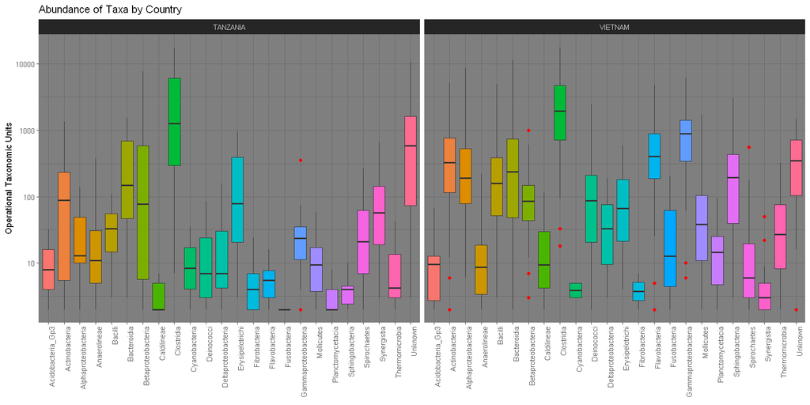

```r
# Alter my_plot and fix the x-axis
my_plot +
    theme_dark() +
    theme(axis.text.x = element_text(angle = 90, hjust=1))
```

## 3.3.2 More themes are found in the `ggthemes` package

`ggthemes` is a package of themes. Some of these themes are based off of graphs seen in print or on websites (the economist, wall street journal, fivethirtyeight) or to match standard tools (excel, google docs). Information about these themes can be found at https://github.com/jrnold/ggthemes.

Here are 2 possible themes.

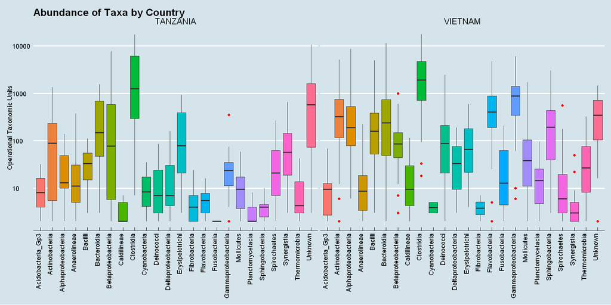

```r
# Load the ggthemes package
library(ggthemes)

# Add the economist theme to our plot
my_plot +
    theme_economist() +
    theme(axis.text.x = element_text(angle=90, hjust=1))
```

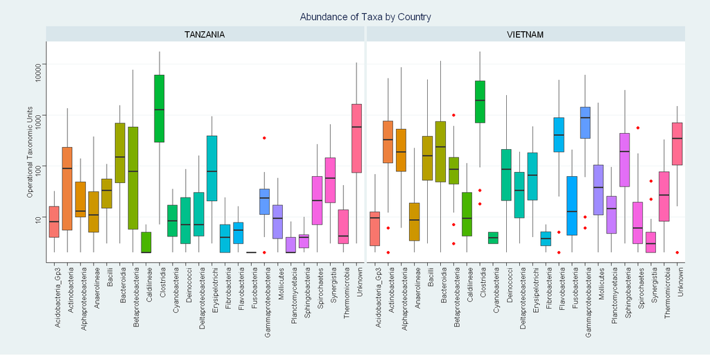

```r
# An example of replicating the style from "Stata" software
my_plot +
    theme_stata() +
    theme(axis.text.x = element_text(angle=90, hjust=1))
```

## 3.4.0 Make a customized theme

You can also make your own custom theme as demoed here: http://joeystanley.com/blog/custom-themes-in-ggplot2

I am going to show you how to customize a plot, starting from `theme_minimal()` because I don't like the grey backgrounds or harsh axis lines.

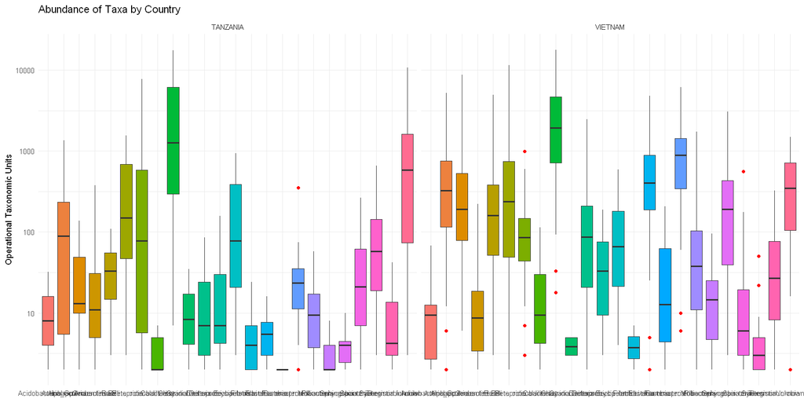

```r
# Start by using the minimal theme
my_plot +
    theme_minimal()
```

Things I don't like about this plot and their solutions:

| Problem | Solution |
| --- | --- |
| x-axis labels overlap and are small | rotate lables: axis.text.x = element_text(angle =90, hjust=1, vjust=0.5, size=14) |
| country labels are smaller than axis labels | change size and face: strip.text.x = element_text(face = 'bold', size = 16) |
| title is uncentered | adjust horizontally: plot.title = element_text(hjust=0.5, size = 18) |
| border to separate countries | create a border: panel.border = element_rect(fill = NA) |
| make y axis ticks | create y axis ticks: axis.ticks.y = element_line() |

It isn't necessary to remember all of this syntax. I frequently find myself back at the help page at http://ggplot2.tidyverse.org/reference/theme.html.

As mentioned the last call to `theme()` will override previous calls that conflict. Therefore, if we want to start with `theme_minimal()` as our base, it has to be in our code BEFORE the other modifications.

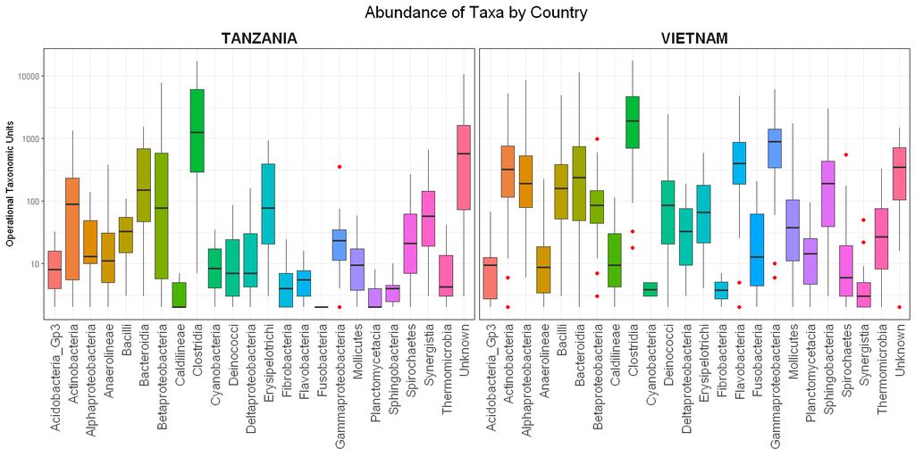

```r
# Add our own theme elements
my_plot +
  theme_minimal() +
  theme(axis.text.x = element_text(angle = 90, hjust = 1, vjust =0.5, size=14),
        panel.border = element_rect(fill=NA),
        strip.text.x = element_text(face="bold", size=16),
        plot.title = element_text(hjust=0.5, size=18),
        axis.ticks.y = element_line())
```

## 3.4.1 Challenge: Alter plot background and major/minor gridlines

Alter `my_plot` by:

1. Changing the background colour.
2. Adding minor gridlines.
3. Making the major gridlines black.

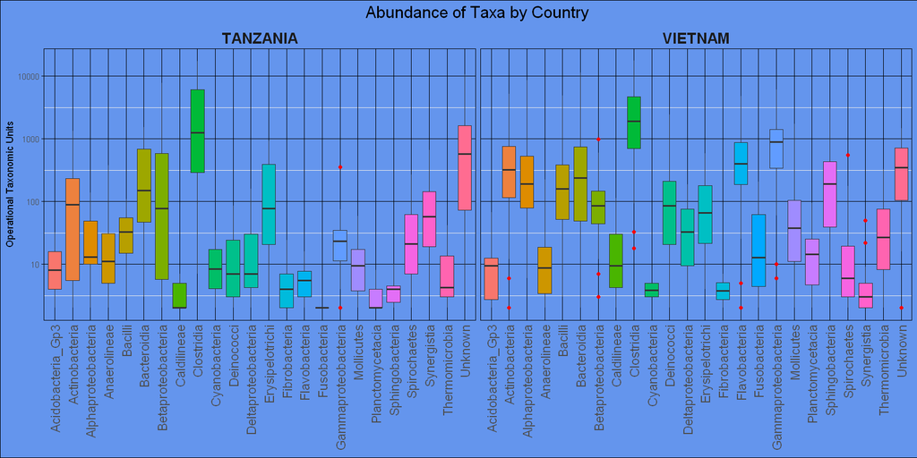

```r
# Fill the blanks
my_plot +
  theme_minimal()+
  theme(axis.text.x = element_text(angle = 90, hjust = 1, vjust=0.5, size=14),
        panel.border = element_rect(fill = NA),
        strip.text.x = element_text(face = "bold", size = 16),
        plot.title = element_text(hjust=0.5, size = 18),
        axis.ticks.y = element_line(),
        plot.background = element_rect(fill = "cornflowerblue"),
        panel.grid.minor = element_line(),
        panel.grid.major = element_line(colour="black")
        )
```

There are a lot of way to customize your plots! Keep exploring and playing with parameters!

## 4.0.0 Saving your figures

Up until now, we have taken for granted that our plots have been displayed using a *Graphic Device*.

</br>

## 4.1.0 Graphics Devices

- Plots must be created on a graphics device
- The default graphics device is almost always the screen device, which is most useful for exploratory analysis.
- File devices are useful for creating plots that can be included in other documents or sent to other people.
- For file devices, there are vector (pdf, svg, postscript) and bitmap (png, jpeg, tiff) formats.
- Vector formats are good for line drawings and plots with solid colors using a modest number of points.
- Bitmap formats are good for plots with a large number of points, natural scenes or web-based plots.

(https://rdpeng.github.io/Biostat776/notes/pdf/grdevices.pdf)

`ggplot2` has its own function for saving its graphics: `ggsave()`. This allows us to skip the step of explicitly calling separate graphics devices and shutting them down afterwards (if you have saved plots in base R or `lattice`, this will sound familiar to you).

You can send the plot object to the screen device to preview your image, and then save that image by specifying the file device. If you do not specify the device type, `ggsave()` will guess it from your filename extension (pdf, jpeg, tiff, bmp, svg or png). Note that this will save whatever graphic was last on your screen device.

With `ggsave()` you can minimally input the filename you would like to have, and the path to your file.

```r
# Save the last plot displayed by ggplot
ggsave("crazy_blue_graph.png", path = "data")
```

However, in some cases you want to tailor your output. You can specify the width, height and units of your image, or you can apply a scaling factor (the 'eyeballing' approach). You can also specify the plot object you want to save instead of whatever was on your graphics device last using the 'plot' parameter. Note that this time I have combined the path with the filename, and called the file device type separately.

```r
# Save our altered plot to an object
saved_plot <- my_plot + theme_minimal()+
  theme(axis.text.x = element_text(angle = 90, hjust = 1, vjust=0.5, size=14),
        panel.border = element_rect(fill = NA),
        strip.text.x = element_text(face = "bold", size = 16),
        plot.title = element_text(hjust=0.5, size = 18),
        axis.ticks.y = element_line(),
        panel.grid.major = element_line(),
        panel.grid.minor = element_line(),
        plot.background = element_rect(fill = "cornflowerblue"))

# Specifically make saved_plot a pdf!
ggsave("data/crazy_blue_graph2.pdf", plot = saved_plot, device = "pdf", scale = 2, width=250, height=110, unit = "mm")
```

No image is sent to the screen device when a file is saved in this manner.

## 5.0.0 Taking it up a notch

There are many fantastic R packages to analyze and visualize your data. As a group, we are likely working in a variety of specialized areas. The plots we have made so far today should be useful for data exploration for many different kinds of data. In the next section we are going to preview some more complex visualization types, but since these take more time to go through and not everyone may be interested in interactive graphics, network diagrams, time-series analysis, or geospatial data, we will not be plotting all of these together. We will, however learn how to arrange multiple plots per page, and also how to make an upset plot.

## 5.1.0 Multiple plots on one page (ie. for publication images) with `ggarrange()`

There are a variety of methods to mix multiple graphs on the same page, however `ggplot2` does not work well with all of them. I am going to work with a package base that uses `gridExtra`(which allows us to arrange plots) but works well with `ggplot2` called `ggpubr` (which allows us to align the axes of our plots). For a demonstration, we are going to take 3 plots that we made earlier (a boxplot, a histogram, and a dot plot), save them as objects, and then arrange and align them in the same figure. (http://www.sthda.com/english/rpkgs/ggpubr/)

```
Warning message:
"Removed 158 rows containing non-finite values (stat_bin)."
Warning message:
"Removed 3 rows containing missing values (geom_bar)."
```

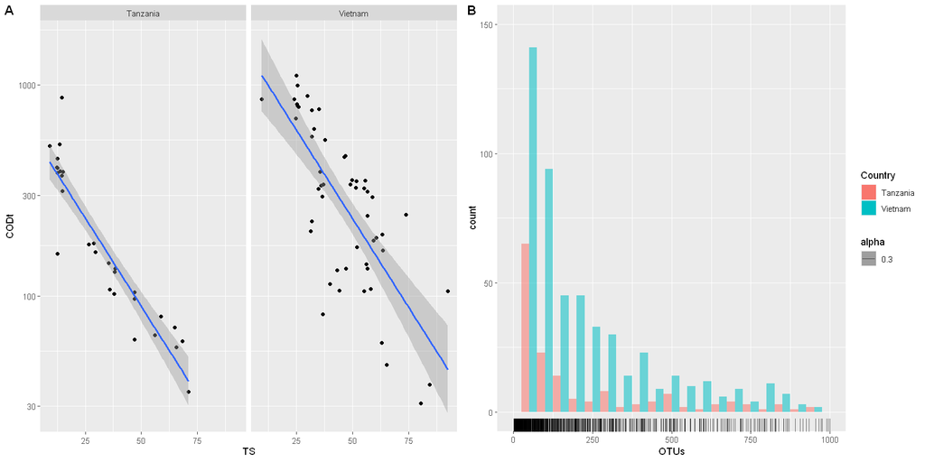

```r
# Load the ggpubr package
library(ggpubr)

# Create a histogram
hist <- ggplot(filtered_latrines, aes(x=OTUs, fill=Country, alpha=0.3)) +
    geom_histogram(binwidth = 50, position = "dodge") +
    xlim(0,1000) +
    ylim(0,150) +
    geom_rug()

# Create a dot plot
dot <- ggplot(metadata, aes(x=TS, y=CODt)) +
    geom_point() +
    scale_y_log10() +
    facet_grid(~Country) +
    stat_smooth(method = lm)

# Arrange the two plots in a single page
ggarrange(dot, hist, labels = c("A", "B"), ncol=2, nrow=1)
```

## 5.1.1 Sometimes you need to shuffle things around to make it nice

While the grid areas are of the same size, the backgrounds are not. Let's adjust the legend so that it is in the top right corner of the plot, and remove the white background. We do not need the alpha legend. Do you remember how to get rid of it?

Remember:

1. Alter legends with the `guides()` option
2. `legend.position` uses a tuple where each value is {0,1}. (0,0) is the lower-left and (1,1) is the upper-right of a graph. You can also specify "left", "right", "top", and "bottom" for positions *outside* your graph.

```
Warning message:
"Removed 158 rows containing non-finite values (stat_bin)."
Warning message:
"Removed 3 rows containing missing values (geom_bar)."
```

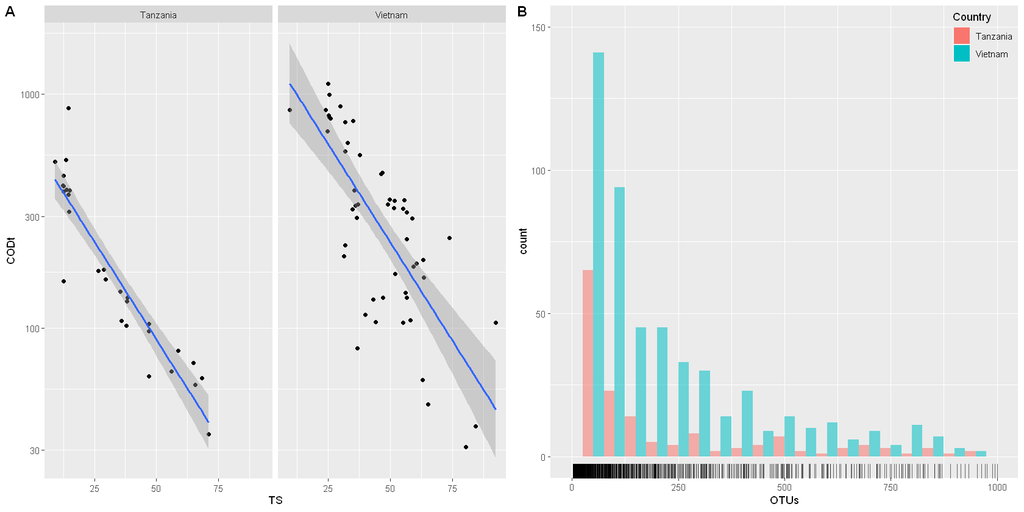

```r
hist <- ggplot(filtered_latrines, aes(x=OTUs, fill=Country, alpha=0.3)) +
    geom_histogram(binwidth = 50, position = "dodge") +
    xlim(0,1000) +
    ylim(0,150) +
    geom_rug() +
    guides(alpha = FALSE) + # Remove the alpha legend
    theme(legend.justification = c(1,1), legend.position = c(1,1), legend.background = element_blank()) # Move our bar legend


ggarrange(dot, hist,
          labels = c("A", "B"),
          ncol = 2, nrow = 1)
```

## 5.1.2 Arrange plots within plots

Next we will add in the boxplot by nesting a `ggarrange()` call within another.

Imagine a square with 4 boxes.

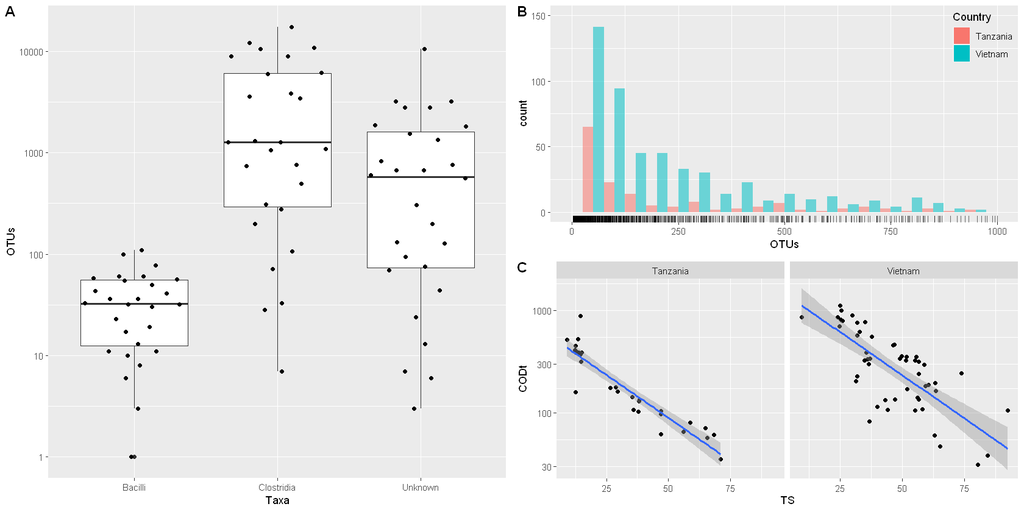

```r
# Set up a boxplot for our example
box <- ggplot(subdat , aes(x = Taxa, y = OTUs)) +
    geom_boxplot() +
    geom_quasirandom(varwidth=TRUE) +
    #theme(axis.text.x = element_text(angle=90, hjust=1)) +
    scale_y_log10()

ggarrange(box, # First call
          ggarrange(hist, dot, # nested call
                    labels = c("B", "C"),
                    nrow = 2),
          ncol = 2, labels = "A")
```

## 5.1.3 Small changes can be made with `align` and `font()`

If y-axis lines or x-axis lines are not aligned, this can be fixed with a call to `align = "v"` or `align="h"`.

To make sure all axis titles are the same size (B and C look a little off to me), we can specify using `font()` which text we want changed and the size we want to change it to. I am also going to make the legend title size the same. Let's look at the `font()` function. You'll notice it's still not quite perfect but better in many places.

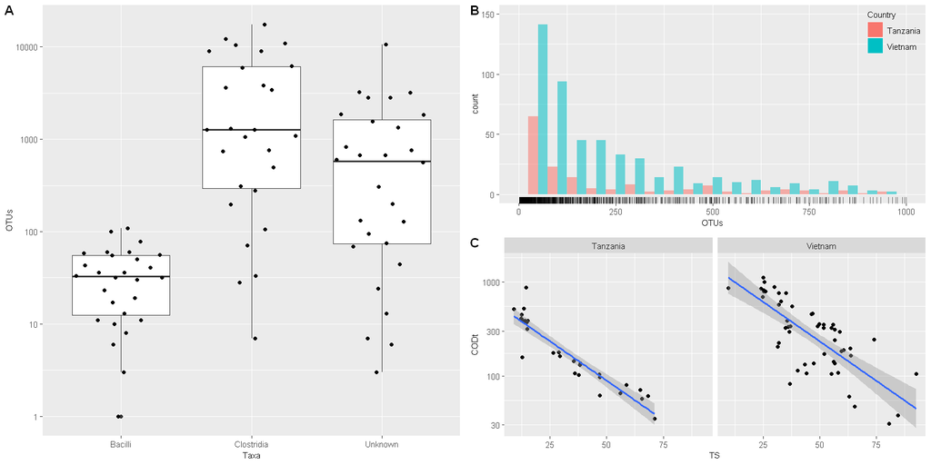

```r
ggarrange(box + font("axis.title", size=9),
          ggarrange(hist + font("axis.title", size=9) +
                    font("legend.title", size=9),
                    dot +
                    font("axis.title", size=9),
                    labels = c("B", "C"),
                    nrow = 2, align = "v"),
           ncol = 2, labels = "A")
```

## 5.2.0 Challenge: Make a combined image with a panel across the top

Using the code available here for a density plot we made earlier in the lesson, make a combined figure. Imagine a square with 4 boxes. We are going to put our density plot in the top left and right boxes, the histogram in the bottom left box, and the box plot in the bottom right box. Make sure the legend and axis titles are the same size. Change the legend text for the line graph to be smaller than the legend title.

```r
# Remake our density plot from earlier
dens <- ggplot(filtered_latrines, aes(x=OTUs, fill=Country, alpha=0.3)) +
    geom_density() +
    geom_rug() +
    xlim(0, 1000) +
    theme(legend.justification=c(1,1), legend.position=c(1,1), legend.background = element_blank())
```

```r
# Let's arrange a new set of panels
ggarrange(dens +
          ... +
          ... +
          ..., # So we've set axis and legend titles to 9, legend text to 6
          ggarrange(hist +
                    font("axis.title", size=9) +
                    font("legend.text", size = 6) +
                    font("legend.title", size=9), # subpanel histogram with the same properties
                    box +
                    font("axis.title", size=9), # subpanel boxplot with size 9 axis title
                    labels = c("B", "C"), # label the subpanels as B and C
                    ncol = 2, align = "h"), # set 2 columns in this subpanel
          nrow = 2, labels = "A") # set two rows for the main panel
```

## 5.3.0 Upset plots

## 5.3.1 Can Upset plots help us to make sense of overlapping relationships?

`UpSetR`: https://github.com/hms-dbmi/UpSetR

</br>

## 5.3.2 Working with `UpsetR` to visualize overlapping datasets

Let's see how UpSet plots work practically.

*Question: For 8 Taxa, how many sites are those Taxa present at, and what is the overlap between sites with other Taxa?*

I have picked 8 different Taxa, which would make a crazy venn diagram with a lot of zeros in it since a couple of these Taxa are rare.

```r
subtax <- read.csv("data/SPE_pitlatrine.csv", stringsAsFactors = FALSE)

eight <- c("Chloroflexi", "Acidobacteria_Gp16", "Acidobacteria_Gp5", "Cyanobacteria",
           "Lentisphaeria", "Deinococci", "Alphaproteobacteria", "Clostridia")

#subset for the 8 taxa
subtax <- subtax %>% filter(Taxa %in% eight)

subtax
```

A data.frame: 8 × 82

| Taxa <chr> | T_2_1 <int> | T_2_10 <int> | T_2_12 <int> | T_2_2 <int> | T_2_3 <int> | T_2_6 <int> | T_2_7 <int> | T_2_9 <int> | T_3_2 <int> | ... | V_6_2 <int> | V_6_3 <int> | V_7_1 <int> | V_7_2 <int> | V_7_3 <int> | V_8_2 <int> | V_9_1 <int> | V_9_2 <int> | V_9_3 <int> | V_9_4 <int> |
| --- | --- | --- | --- | --- | --- | --- | --- | --- | --- | --- | --- | --- | --- | --- | --- | --- | --- | --- | --- | --- |
| Acidobacteria_Gp16 | 0 | 0 | 0 | 0 | 0 | 0 | 0 | 0 | 0 | ... | 0 | 0 | 0 | 0 | 0 | 0 | 0 | 0 | 0 | 0 |
| Acidobacteria_Gp5 | 0 | 0 | 0 | 0 | 0 | 0 | 0 | 0 | 0 | ... | 0 | 0 | 0 | 0 | 8 | 0 | 0 | 0 | 0 | 0 |
| Alphaproteobacteria | 11 | 0 | 2 | 21 | 11 | 49 | 0 | 71 | 13 | ... | 592 | 589 | 90 | 632 | 510 | 1000 | 27 | 122 | 1 | 411 |
| Chloroflexi | 0 | 0 | 0 | 0 | 0 | 0 | 0 | 0 | 0 | ... | 0 | 0 | 0 | 0 | 0 | 0 | 0 | 0 | 0 | 0 |
| Clostridia | 6213 | 71 | 0 | 8999 | 10944 | 12169 | 28 | 17471 | 3431 | ... | 6048 | 1432 | 4213 | 717 | 3134 | 3084 | 2356 | 143 | 18 | 3051 |
| Cyanobacteria | 0 | 0 | 0 | 0 | 0 | 0 | 0 | 0 | 0 | ... | 0 | 1 | 1 | 3 | 0 | 0 | 0 | 0 | 0 | 1 |
| Deinococci | 0 | 0 | 0 | 0 | 0 | 3 | 0 | 2 | 1 | ... | 104 | 292 | 51 | 197 | 81 | 1102 | 9 | 61 | 2 | 88 |
| Lentisphaeria | 0 | 0 | 0 | 0 | 0 | 1 | 0 | 1 | 0 | ... | 0 | 0 | 0 | 0 | 0 | 0 | 2 | 0 | 0 | 0 |

The data that we have is an OTU table. It is 8 rows (as expected) by 82 columns (81 sample entries)

For this purpose we simply want to know whether a given Taxa was present or absent in the sample, and then we can form intersections based on this information. So, for each OTU value that is *not* 0, we replace it with a 1 instead.

```r
# This is a tidyr way of transposing our data frame so Taxa are in columns and sites are in rows.
# This format is for the UpSet plot only (we can do the value replacement in either format)
subtax  <- subtax %>%
   gather(key="sample", value="otus", -Taxa) %>%
   spread(Taxa, otus)

head(subtax)
```

A data.frame: 6 × 9

|  | sample <chr> | Acidobacteria_Gp16 <int> | Acidobacteria_Gp5 <int> | Alphaproteobacteria <int> | Chloroflexi <int> | Clostridia <int> | Cyanobacteria <int> | Deinococci <int> | Lentisphaeria <int> |
| --- | --- | --- | --- | --- | --- | --- | --- | --- | --- |
| 1 | T_2_1 | 0 | 0 | 11 | 0 | 6213 | 0 | 0 | 0 |
| 2 | T_2_10 | 0 | 0 | 0 | 0 | 71 | 0 | 0 | 0 |
| 3 | T_2_12 | 0 | 0 | 2 | 0 | 0 | 0 | 0 | 0 |
| 4 | T_2_2 | 0 | 0 | 21 | 0 | 8999 | 0 | 0 | 0 |
| 5 | T_2_3 | 0 | 0 | 11 | 0 | 10944 | 0 | 0 | 0 |
| 6 | T_2_6 | 0 | 0 | 49 | 0 | 12169 | 0 | 3 | 1 |

```r
# If any OTUs are present, substitute the value with a 1 (exclude the first row which is character).
#Take a look at the apply function syntax:

subtax[,-1] <- apply(subtax[-1],
                     2, # Margin to apply the function over. 1 = rows, 2 = columns
                     function(x) ifelse(x!=0, 1, 0)) # Conditional statement

head(subtax)
```

A data.frame: 6 × 9

|  | sample <chr> | Acidobacteria_Gp16 <dbl> | Acidobacteria_Gp5 <dbl> | Alphaproteobacteria <dbl> | Chloroflexi <dbl> | Clostridia <dbl> | Cyanobacteria <dbl> | Deinococci <dbl> | Lentisphaeria <dbl> |
| --- | --- | --- | --- | --- | --- | --- | --- | --- | --- |
| 1 | T_2_1 | 0 | 0 | 1 | 0 | 1 | 0 | 0 | 0 |
| 2 | T_2_10 | 0 | 0 | 0 | 0 | 1 | 0 | 0 | 0 |
| 3 | T_2_12 | 0 | 0 | 1 | 0 | 0 | 0 | 0 | 0 |
| 4 | T_2_2 | 0 | 0 | 1 | 0 | 1 | 0 | 0 | 0 |
| 5 | T_2_3 | 0 | 0 | 1 | 0 | 1 | 0 | 0 | 0 |
| 6 | T_2_6 | 0 | 0 | 1 | 0 | 1 | 0 | 1 | 1 |

Our table `subtax` is now 81 rows (samples) by 9 columns (8 taxa that we are investigating)

Then to use the `upset()` plotting function, we enter our data set, the number of sets we are inputting, if we want to order the results (in this case by frequency), and how many intersections we want to show. Here, I will show 15 intersections - we know the remaining intersections would be zero since this is ordered by frequency.

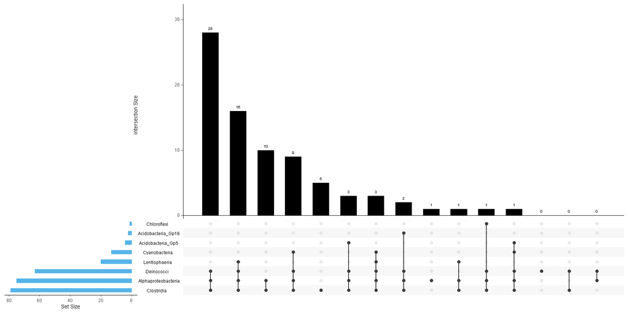

```r
library(UpSetR)

upset(subtax, nsets = 8,
     empty.intersection = TRUE,
     order.by = "freq",
     nintersects = 15,
     main.bar.color = "black",
     sets.bar.color = "#56B4E9")

# This UpSet plot show taxa co-occurrence -taxa found together
```

## 5.3.3 Understanding our Upset plot

Our plot can be broken into 3 sections.

1. The left-hand barplot denotes the number of observations in each set/category.
2. The bottom plot graphically represents the different combinations of each category up to `nintersects`.
3. The upper barplot displays the number of occurences for the combination diplayed in the bottom plot.

From our result, our greatest intersection size is (equal to 28). This means that 28 of our 81 samples have *Clostridia*, *Alphaproteobacteria*, and *Deinococci* present in the same sample WITHOUT *Chloroflexi*, both *Acidobacteria*, *Cyanobacteria* and *Lentisphaeria*.

We can see from the Set Size that *Clostridia* and *Alphaproteobacteria* are present in almost all samples, and *Deinococci* is present in greater than 3/4 of the samples. You might expect this overlap to be higher, but remember that this is without all the other Taxa.

Moving along our interesection sizes and dot matrix, we can see that other intersections include these bacteria. For example, the next bar to the right with an intersection size of 16, also includes *Lentisphaeria*. Some quick mental math shows that 63 samples have these top 3 Taxa present.

## 5.4.0 Other graphics packages

## 5.4.1 Interactive graphics

`Plotly`: https://plot.ly/r/

`ggvis`: http://ggvis.rstudio.com/interactivity.html

Heatmaps: https://github.com/talgalili/heatmaply

Interactive time-series data: https://rstudio.github.io/dygraphs/

## 5.4.2 Network diagrams

`visNetwork` (based on igraph): https://datastorm-open.github.io/visNetwork/edges.html

## 5.4.3 Circos Plots

Migest: https://gjabel.wordpress.com/category/r/migest/

## 5.4.4 Geospatial Data

Static Maps:

- https://bhaskarvk.github.io/user2017.geodataviz/notebooks/02-Static-Maps.nb.html

Interactive Maps:

- https://bhaskarvk.github.io/user2017.geodataviz/notebooks/03-Interactive-Maps.nb.html

## 5.4.5 Phylogenetics Data

`ggtree`:

- http://www.bioconductor.org/packages/3.7/bioc/vignettes/ggtree/inst/doc/treeAnnotation.html#annotate-clades

`treeman`:

- https://bmcresnotes.biomedcentral.com/articles/10.1186/s13104-016-2340-8

`metacoder`:

- https://github.com/grunwaldlab/metacoder

`phyloseq`:

- https://joey711.github.io/phyloseq/index.html

## 5.4.6 Genomics Data

`ggbio`:

- http://www.bioconductor.org/packages/2.11/bioc/vignettes/ggbio/inst/doc/ggbio.pdf

`GenVisR`:

- https://bioconductor.org/packages/release/bioc/vignettes/GenVisR/inst/doc/Intro.html

`GenomeGraphs`:

- https://bmcbioinformatics.biomedcentral.com/articles/10.1186/1471-2105-10-2

## 5.5.0 Just for fun...

**Challenge**

Install and load the gapminder package. Save the gapminder data into an object using `latrines <- gapminder`. Plot the following:

1. a qualitative variable with a quantitative variable (at least 2 ways).
   - Facet your plot by the qualitative variable.
2. two quantitative variables (at least 2 ways).
   - Add a regression line to your plot.

## 6.0.0 Resources

Wickham, Hadley. (2010). A Layered Grammar of Graphics. Journal of Computational and Statistical Graphics.  
Wilkinson, L. (2005), The Grammar of Graphics (2nd ed.). Statistics and Computing, New York: Springer. [14, 18]  
Tufte, Edward R. The Visual Display of Quantitative Information.

http://www.cookbook-r.com/Graphs/  
https://github.com/jennybc/ggplot2-tutorial  
http://stcorp.nl/R_course/tutorial_ggplot2.html  
http://ggplot2.tidyverse.org/reference/theme.html  
http://joeystanley.com/blog/custom-themes-in-ggplot2  
https://github.com/jrnold/ggthemes  
https://www.nceas.ucsb.edu/~frazier/RSpatialGuides/colorPaletteCheatsheet.pdf  
https://cran.r-project.org/web/packages/ggrepel/vignettes/ggrepel.html  
http://www.cookbook-r.com/Graphs/Legends_(ggplot2)/  
https://github.com/eclarke/ggbeeswarm  
https://cran.r-project.org/web/packages/ggsci/vignettes/ggsci.html  
http://www.sthda.com/english/rpkgs/ggpubr/  
https://rpubs.com/drsong/9575  
http://elpub.bib.uni-wuppertal.de/edocs/dokumente/fbb/wirtschaftswissenschaft/sdp/sdp15/sdp15006.pdf  
http://www.sthda.com/english/articles/24-ggpubr-publication-ready-plots/81-ggplot2-easy-way-to-mix-multiple-graphs-on-the-same-page/  
https://rdpeng.github.io/Biostat776/notes/pdf/grdevices.pdf

## 6.1.0 Post-lesson assessment

Soon after the end of this lecture, a homework will be available for you on [DataCamp](https://www.datacamp.com/). You will have until 12:00 hours on Thursday, February 18th, to complete the assignment (right before the next lecture). This is a pass-fail assignment where you need to achieve a least 75% out of the total points possible to pass.

Thanks for coming!!!

[figure not shown]

## 7.0.0 Appendix

## 7.1.0 Circular plots

In `ggplot2`, circular plots are related to bar graphs - they just have different *coordinate systems*. The default coordinate system is cartesian coordinates, and we need to switch to polar coordinates to make a circle. This is a Coxcomb plot - pH levels increase as you move up the outer rings, and depth increases as you move clockwise around the circle. Colour is still represented by country.

```r
ggplot(metadata, aes(x=Depth, y=pH, fill = Country)) +
    geom_bar(stat="identity", position = "dodge") +
    coord_polar()
```

## 7.2.0 Classic pie chart

To make your classic pie chart, use theta to specify what variable is going to be used to make up the angles (width of pie slices). To wrap to a full circle instead of having sections (as in the above Coxcomb plot), the width is set to one.

```r
ggplot(latrines, aes(x="", y=Country, fill = Country)) +
    geom_bar(stat = "identity", width = 1) +
    coord_polar(theta = "y")
```

## 7.3.0 Lines

To draw a line graph, we select `geom_line()`.

```r
ggplot(metadata, aes(x=Temp, y=pH)) + geom_line()
```

We can colour the lines for the different countries. Looking at our previous graph, what must have happened when these values were over the same range?

```r
ggplot(metadata, aes(x=Temp, y=pH, colour = Country)) + geom_line()
```

## 7.4.0 Error bars

To plot error bars, we need to give the geom, `geom_errorbar()`, and the interval over which we want to draw the bar. This interval is usually one standard deviation, one standard error or a confidence interval.

Luckily, we have learned how to calculate the mean and standard deviation with `dplyr`. Once we have that, all we need to do is add or subtract the standard deviation from our data points to get the bounds of the error bar.

`geom_errorbar()` takes these bounds passed to the parameters ymax and ymin. In this case, since there were no sample replicates the standard deviation is taken from the mean of all of the soil readings in a given country at a given depth.

```r
# Pregenerate the error bar data by adding a mean and standard deviation variable
errdat <- metadata %>% group_by(Country, Depth) %>% mutate(mean_pH = mean(pH)) %>% mutate(sd_pH= sd(pH))

ggplot(errdat, aes(x=Temp, y=pH, colour = Country)) +
    geom_line() +
    geom_errorbar(aes(ymin=pH-sd_pH, ymax = pH+sd_pH), width = 0.2, alpha = 0.4)
```

## 7.5.0 Strip plots look a lot like boxplots without the boxes.

The first plots we made we scatterplots with 2 continuous variables. With one discrete variable and one categorical variable, we can make a stripplot. We use the point geom for both of these types of plots.

```r
ggplot(latrines, aes(x = Depth, y = OTUs)) + geom_point()
```

Again, we have a lot of values crushed near the x-axis. If we add log scaling to the y-axis, we get an error that this transformation created infinite values. This is because we have zeros in our data set.

```r
ggplot(latrines, aes(x = Depth, y = OTUs)) +
    geom_point() +
    scale_y_log10()
```

Knowing this, we could ignore the warning, or add +1 to each OTU (negligable on a log scale).

```r
ggplot(latrines, aes(x = Depth, y = OTUs+1)) +
    geom_point() +
    scale_y_log10()
```

In order to see the points a little better, we can 'jitter' them. Jittering spreads out our data points while keeping them in the same area of the plot so we can get an idea of density.

```r
ggplot(latrines, aes(x = Depth, y = OTUs+1)) +
    geom_point(position = "jitter") +
    scale_y_log10() +
    facet_wrap(~Country)
```

## 7.6.0 Bubble Plots can visualize differences by point size

With bubble plots, we need to provide the size of our bubbles in a way that is proportional to our data, and provide a scale to map these to.

Let's group our OTUs by Country and Taxa and look at the Taxa for the top 30 OTUs. As a refresher, try to do this using `dplyr` functions.

We are going to make our bubbles (which can be thought of as large points) with `geom_jitter()` so that our bubbles don't overlap. Remember that we want to specify what we are plotting with **aesthetics**. We want the bubbles representing OTUs_per_Taxa, so we divide each value by pi when calling size.

```r
# Make a data set of the top 30 Taxa with highest total OTUs in a single country
bubble_latrines <- latrines %>%
    group_by(Taxa, Country) %>%
    mutate(OTUs_per_Taxa = sum(OTUs)) %>%
    arrange(desc(OTUs_per_Taxa)) %>%
    select(Taxa, Country, OTUs_per_Taxa) %>%
    unique() %>%
    .[1:30,]

# Plot the data but alter the size based on a variable like OTUs_per_Taxa
ggplot(bubble_latrines, aes(x = Country, y = OTUs_per_Taxa, fill=Taxa)) +
    scale_y_log10() +
    geom_jitter(aes(size = OTUs_per_Taxa/pi), pch = 21, show.legend = TRUE)  +
    guides(fill = FALSE)
```

However, it is hard to tell proportionally how different these sizes are. Mapping values to a scale gives us more of an idea of their relative sizes. This is done by giving a range of values to `scale_size_continuous()`. This range is the size you want your plotting symbols (bubbles) to be after transformation. You can use trial and error to see what range you like; it is not changing your data, but rather your perception of the data.

```r
ggplot(bubble_latrines, aes(x = Country, y = OTUs_per_Taxa, fill=Taxa)) +
    scale_y_log10() +
    geom_jitter(aes(size = OTUs_per_Taxa/pi), pch = 21, show.legend = FALSE) +
    scale_size_continuous(range=c(1,30)) +
    guides(fill=FALSE)
```

## 7.7.0 Labelling data points

`ggplot2` provides 2 methods of labelling: `geom_label()` and `geom_text()`. Let's look at the help menu to find out what the difference between them is.

We have to specify with **aesthetics** what we are plotting for our label.

```r
ggplot(bubble_latrines, aes(x = Country, y = OTUs_per_Taxa, fill=Taxa)) +
    scale_y_log10() +
    geom_jitter(aes(size = OTUs_per_Taxa/pi), pch = 21, show.legend = FALSE) +
    scale_size_continuous(range=c(1,30)) +
    geom_label(aes(label = Taxa), show.legend = FALSE)
```

This isn't fantastic because our labels are overlapping. What parameters might you be able to use to move the labels? Try using them to get the labels to not overlap.

The text geom has an option to check for overlap of labels. `geom_text()` does not provide a background for the label, and it may be harder to tell which label belongs to each data point.

```r
ggplot(bubble_latrines, aes(x = Country, y = OTUs_per_Taxa, fill=Taxa)) +
    scale_y_log10() +
    geom_jitter(aes(size = sqrt(OTUs_per_Taxa/pi)), pch = 21, show.legend = FALSE) +
    scale_size_continuous(range=c(1,30)) +
    geom_text(aes(label = Taxa), check_overlap = TRUE, show.legend = FALSE)
```

What happened here? Why don't we have as many labels? Look in the help menu to explain this behaviour.

I don't like futzing with label positions, so I went looking for a package that would do this for me. `ggrepel` will 'repel' your labels away from each other without getting rid of them. Let's check it out with our bubble plot labels. Install and load `ggrepel`. The equivalent function we can use is `geom_label_repel()`. The force parameter allow you to modify how far you want your labels pushed away from each other.

Here, the box colour is being used to map to our data points but `ggrepel` can instead connect a line to data points by altering the value of segment.size. Variations on use can be found here: https://cran.r-project.org/web/packages/ggrepel/vignettes/ggrepel.html.

```r
# Load up the ggrepel package
library(ggrepel)

ggplot(bubble_latrines, aes(x = Country, y = OTUs_per_Taxa, fill=Taxa)) +
    scale_y_log10() +
    geom_jitter(aes(size = sqrt(OTUs_per_Taxa/pi)), pch = 21, show.legend = FALSE) +
    scale_size_continuous(range=c(1,30)) +
    geom_label_repel(aes(label = Taxa), force = 2, show.legend = FALSE, segment.size = 0)
```